# k_nearest_neighbor

Justin Sarna

April 20, 2017

```r
# read in the data
acs <- read.table("http://jaredlander.com/data/acs_ny.csv",sep=",",
                  header=TRUE, stringsAsFactors=TRUE)
```

## Create some new variables based on EDA

1. This chunk of code is the same for all pages in this R-project
2. It is included in each rmd file so that you can examine each predictive method individually
3. See data_exploration for reasoning/logic

```r
# Load the necessary libraries
library(ggplot2)
library(useful)
library(caret)
library(ISLR)
library(scales)
library(plyr)
library(rpart)
library(rpart.plot)
library(class)
library(MuMIn)
library(caret)
library(dplyr)
library(RColorBrewer)
library(randomForest)
library(kernlab)
library(nlme)
library(lme4)
library(mgcv)
# code from hw4 to be used for creating additional models
acs$HighIncome <- as.numeric(with(acs, FamilyIncome >= 250000))
acs$foodstamp_binary <- ifelse(acs$FoodStamp == "Yes",1,0) # (yes = 1, no = 0)
acs$own_home <- ifelse(acs$OwnRent == "Rented",0, ifelse(acs$FamilyIncome == "Mortgage",1,2)) # (own = 1, rent = 0)
acs$family_type_cat <- ifelse(acs$FamilyType == "Married",1, ifelse(acs$FamilyIncome == "Female Head",2,3))

# married = 1, male head = 2, female head = 3
acs$InsuranceHigh <- (acs$Insurance > 1000) * 1
acs$NumWorkers2 <- (acs$NumWorkers == 2) * 1
acs$HouseCostsHigh <- (acs$HouseCosts > 1000) * 1
acs$high_electric <- (acs$ElectricBill > 350) * 1

# Break it into a training and test set with an 80/20 split.
set.seed(447)
testrecs <- sample(nrow(acs),0.2 * nrow(acs))
acs_test <- acs[testrecs,]
acs_fit <- acs[-testrecs,]

# Create binary variable where 1 = not on food stamps & not renting & married
acs$HI_pred1 <- 0
acs$HI_pred1[acs_test$FoodStamp == 'No' & acs_test$OwnRent != 'Rented' & acs_test$FamilyType == 'Married'] <- 1
acs$null_model <- 0
```

# K-nearest neighbor

1. k-nearest neighbor can only take numerical data
2. It is recommended (in most all cases) to normalize the data set

## First Normalize the dataset

```r
# function to normalize data
normalize <- function(x) {
num <- x - min(x)
denom <- max(x) - min(x)
return (num/denom)
}
```

```r
# create and normalize a new data frame for knn analysis
acs_numericals <- data.frame(acs$NumBedrooms, acs$NumChildren, acs$NumPeople, acs$NumRooms, acs$NumVehicles, acs$NumWorkers, acs$HouseCosts, acs$ElectricBill, acs$Insurance)
acs_norm <- as.data.frame(lapply(acs_numericals[1:8], normalize))
acs_norm$HighIncome1 <- c(acs$HighIncome)
```

## Split data frame into learn and validate subsets

1. Count nunber of rows
2. Create index of random row numbers for validation set
3. Create the learning and validate data sets

```r
m <- nrow(acs_numericals)

val <- sample(1:m, size = round(m/3))

acsNorm_learn <- acs_norm[-val,]
acsNorm_valid <- acs_norm[val,]
```

```r
# view new data frame to verify normalization
summary(acs_norm)
```

```
##  acs.NumBedrooms  acs.NumChildren  acs.NumPeople     acs.NumRooms
##  Min.   :0.0000   Min.   :0.0000   Min.   :0.0000   Min.   :0.0000
##  1st Qu.:0.3750   1st Qu.:0.0000   1st Qu.:0.0000   1st Qu.:0.2500
##  Median :0.3750   Median :0.0000   Median :0.0625   Median :0.3000
##  Mean   :0.4232   Mean   :0.0751   Mean   :0.0869   Mean   :0.3087
##  3rd Qu.:0.5000   3rd Qu.:0.1667   3rd Qu.:0.1250   3rd Qu.:0.3500
##  Max.   :1.0000   Max.   :1.0000   Max.   :1.0000   Max.   :1.0000
##  acs.NumVehicles  acs.NumWorkers   acs.HouseCosts    acs.ElectricBill
##  Min.   :0.0000   Min.   :0.0000   Min.   :0.00000   Min.   :0.0000
##  1st Qu.:0.3333   1st Qu.:0.3333   1st Qu.:0.09117   1st Qu.:0.1710
##  Median :0.3333   Median :0.6667   Median :0.16878   Median :0.2573
##  Mean   :0.3521   Mean   :0.5815   Mean   :0.20836   Mean   :0.3006
##  3rd Qu.:0.5000   3rd Qu.:0.6667   3rd Qu.:0.28168   3rd Qu.:0.3782
##  Max.   :1.0000   Max.   :1.0000   Max.   :1.00000   Max.   :1.0000
##   HighIncome1
##  Min.   :0.00000
##  1st Qu.:0.00000
##  Median :0.00000
##  Mean   :0.06107
##  3rd Qu.:0.00000
##  Max.   :1.00000
```

## knn method

1. specify knn model
2. create a visualization
3. create a confusion matrix

#### knn 1

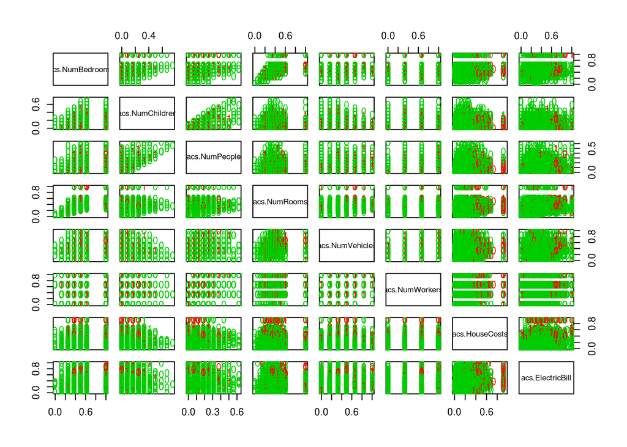

```r
acs_knn1 <- knn(acsNorm_learn[,1:8], acsNorm_valid[,1:8], acsNorm_learn$HighIncome1, k=5, prob = TRUE)
##head(acs_knn1)

pcol1 <- as.character(as.numeric(acsNorm_valid$HighIncome1))
pairs(acsNorm_valid[1:8], pch = pcol1, col = c("green3", "red")
  [(acsNorm_valid$HighIncome1 != acs_knn1)+1])
```

```r
knn1_cm_pred <- confusionMatrix(acs_knn1, acsNorm_valid$HighIncome, positive = "1")
knn1_cm_pred
```

```
## Confusion Matrix and Statistics
##
##           Reference
## Prediction    0    1
##          0 7062  356
##          1   84   80
##
##                Accuracy : 0.942
##                  95% CI : (0.9365, 0.9471)
##     No Information Rate : 0.9425
##     P-Value [Acc > NIR] : 0.5905
##
##                   Kappa : 0.2429
##  Mcnemar's Test P-Value : <2e-16
##
##             Sensitivity : 0.18349
##             Specificity : 0.98825
##          Pos Pred Value : 0.48780
##          Neg Pred Value : 0.95201
##              Prevalence : 0.05750
##          Detection Rate : 0.01055
##    Detection Prevalence : 0.02163
##       Balanced Accuracy : 0.58587
##
##        'Positive' Class : 1
##
```

#### knn 2

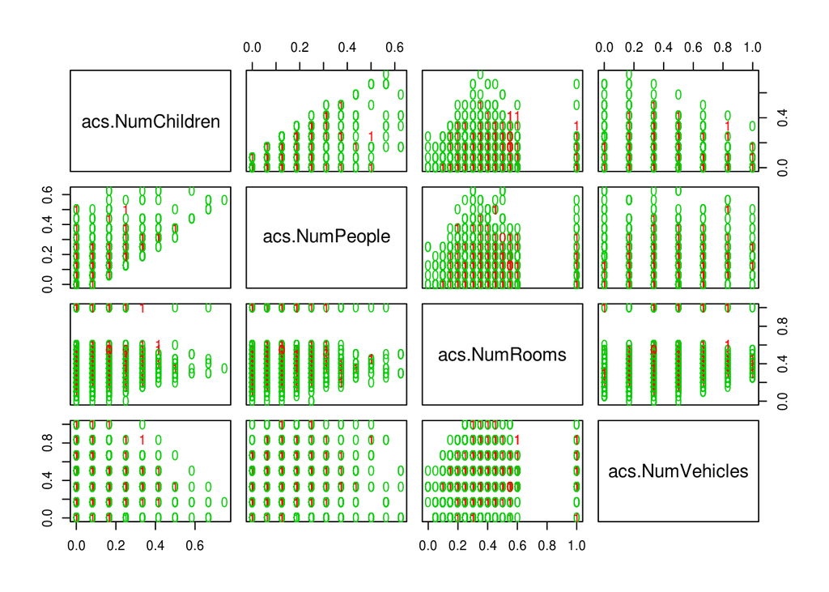

```r
acs_knn2 <- knn(acsNorm_learn[,1:4], acsNorm_valid[,1:4], acsNorm_learn$HighIncome, k=5, prob = TRUE)
##head(acs_knn2)

pcol2 <- as.character(as.numeric(acsNorm_valid$HighIncome1))
pairs(acsNorm_valid[2:5], pch = pcol2, col = c("green3", "red")
  [(acsNorm_valid$HighIncome1 != acs_knn2)+1])
```

```r
knn2_cm_pred <- confusionMatrix(acs_knn2, acsNorm_valid$HighIncome, positive = "1")
knn2_cm_pred
```

```
## Confusion Matrix and Statistics
##
##           Reference
## Prediction    0    1
##          0 7120  429
##          1   26    7
##
##                Accuracy : 0.94
##                  95% CI : (0.9344, 0.9452)
##     No Information Rate : 0.9425
##     P-Value [Acc > NIR] : 0.8321
##
##                   Kappa : 0.0219
##  Mcnemar's Test P-Value : <2e-16
##
##             Sensitivity : 0.0160550
##             Specificity : 0.9963616
##          Pos Pred Value : 0.2121212
##          Neg Pred Value : 0.9431713
##              Prevalence : 0.0575046
##          Detection Rate : 0.0009232
##    Detection Prevalence : 0.0043524
##       Balanced Accuracy : 0.5062083
##
##        'Positive' Class : 1
##
```

#### knn 3

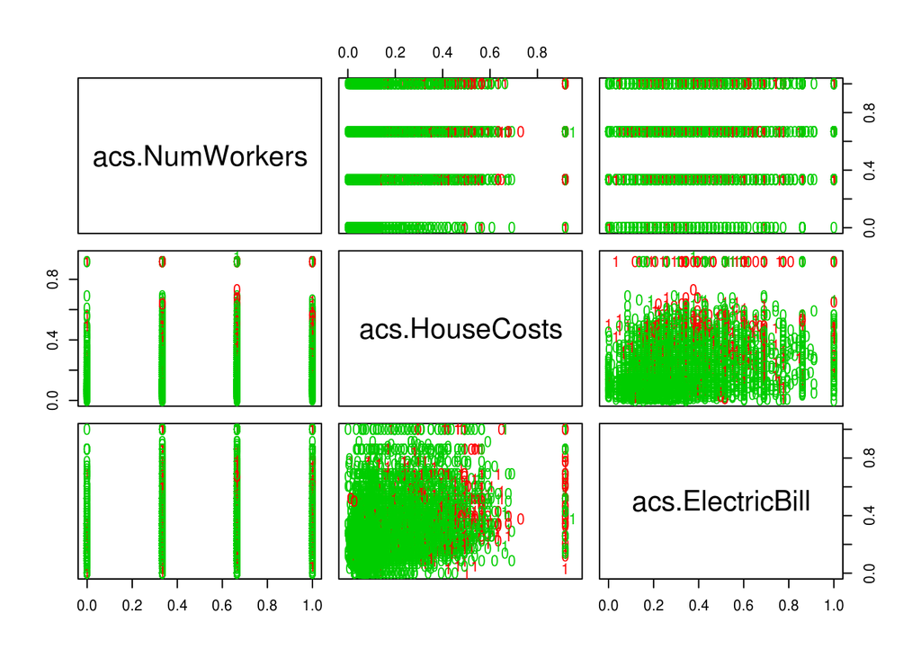

```r
acs_knn3 <- knn(acsNorm_learn[,6:8], acsNorm_valid[,6:8], acsNorm_learn$HighIncome, k=3, prob = TRUE)
##head(acs_knn3)

pcol3 <- as.character(as.numeric(acsNorm_valid$HighIncome1))
pairs(acsNorm_valid[6:8], pch = pcol3, col = c("green3", "red")
  [(acsNorm_valid$HighIncome1 != acs_knn3)+1])
```

```r
knn3_cm_pred <- confusionMatrix(acs_knn3, acsNorm_valid$HighIncome, positive = "1")
knn3_cm_pred
```

```
## Confusion Matrix and Statistics
##
##           Reference
## Prediction    0    1
##          0 7049  363
##          1   97   73
##
##                Accuracy : 0.9393
##                  95% CI : (0.9337, 0.9446)
##     No Information Rate : 0.9425
##     P-Value [Acc > NIR] : 0.886
##
##                   Kappa : 0.2156
##  Mcnemar's Test P-Value : <2e-16
##
##             Sensitivity : 0.167431
##             Specificity : 0.986426
##          Pos Pred Value : 0.429412
##          Neg Pred Value : 0.951025
##              Prevalence : 0.057505
##          Detection Rate : 0.009628
##    Detection Prevalence : 0.022422
##       Balanced Accuracy : 0.576929
##
##        'Positive' Class : 1
##
```

#### knn 4

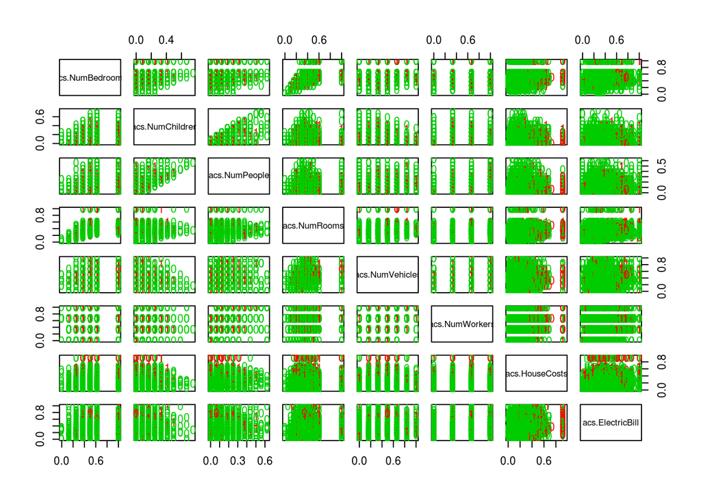

```r
acs_knn4 <- knn(acsNorm_learn[,1:8], acsNorm_valid[,1:8], acsNorm_learn$HighIncome, k=10, prob = TRUE)
##head(acs_knn4)

pcol4 <- as.character(as.numeric(acsNorm_valid$HighIncome1))
pairs(acsNorm_valid[1:8], pch = pcol4, col = c("green3", "red")
  [(acsNorm_valid$HighIncome1 != acs_knn4)+1])
```

```r
knn4_cm_pred <- confusionMatrix(acs_knn4, acsNorm_valid$HighIncome, positive = "1")
knn4_cm_pred
```

```
## Confusion Matrix and Statistics
##
##           Reference
## Prediction    0    1
##          0 7092  364
##          1   54   72
##
##                Accuracy : 0.9449
##                  95% CI : (0.9395, 0.9499)
##     No Information Rate : 0.9425
##     P-Value [Acc > NIR] : 0.1945
##
##                   Kappa : 0.2365
##  Mcnemar's Test P-Value : <2e-16
##
##             Sensitivity : 0.165138
##             Specificity : 0.992443
##          Pos Pred Value : 0.571429
##          Neg Pred Value : 0.951180
##              Prevalence : 0.057505
##          Detection Rate : 0.009496
##    Detection Prevalence : 0.016618
##       Balanced Accuracy : 0.578790
##
##        'Positive' Class : 1
##
```

#### knn 5

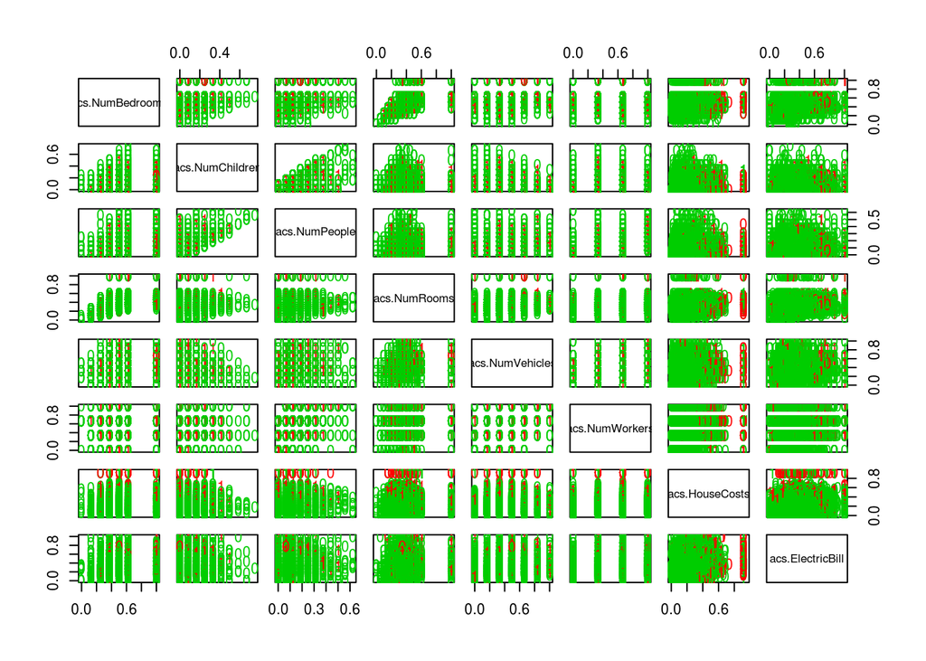

```r
acs_knn5 <- knn(acsNorm_learn[,1:8], acsNorm_valid[,1:8], acsNorm_learn$HighIncome, k=25, prob = TRUE)

#head(acs_knn5)

pcol5 <- as.character(as.numeric(acsNorm_valid$HighIncome1))
pairs(acsNorm_valid[1:8], pch = pcol5, col = c("green3", "red")
  [(acsNorm_valid$HighIncome1 != acs_knn5)+1])
```

```r
knn5_cm_pred <- confusionMatrix(acs_knn5, acsNorm_valid$HighIncome, positive = "1")
knn5_cm_pred
```

```
## Confusion Matrix and Statistics
##
##           Reference
## Prediction    0    1
##          0 7100  372
##          1   46   64
##
##                Accuracy : 0.9449
##                  95% CI : (0.9395, 0.9499)
##     No Information Rate : 0.9425
##     P-Value [Acc > NIR] : 0.1945
##
##                   Kappa : 0.2163
##  Mcnemar's Test P-Value : <2e-16
##
##             Sensitivity : 0.146789
##             Specificity : 0.993563
##          Pos Pred Value : 0.581818
##          Neg Pred Value : 0.950214
##              Prevalence : 0.057505
##          Detection Rate : 0.008441
##    Detection Prevalence : 0.014508
##       Balanced Accuracy : 0.570176
##
##        'Positive' Class : 1
##
```